# Return to Python Projects Page

# City of New York Real-World Fuel Efficiency Exploratory Data Analysis

## Research Question :

## 1.Display top 10 Car Makes with the highest Fuel Consumption

## 2.Display bottom 10 Car Makes with the highest Fuel Consumption

## 3.Display top 10 Car Models with the highest Fuel Consumption

## 4.Display bottom 10 Car Models with the highest Fuel Consumption

## 5.Display Hybrid Cars Vs Non Hybrid Cars Distribution

## 6.Display Car body type Fuel Consumption

## 7 Perform Case Studies on Outliers

## 8 .Provide conclusions after EDA

Datasource : https://catalog.data.gov/dataset/real-world-fuel-efficiency/resource/5668a995-6b32-45e9-b3a4-f45385695a06

```python
# Load in some packages
import calendar
import pandas as pd
import matplotlib.pyplot as plt
import warnings
warnings.filterwarnings("ignore")

fuel_df = pd.read_csv(r"C:\Users\jki\Downloads\Real-World_Fuel_Efficiency.csv")
fuel_df
```

|  | YEAR | MAKE | MODEL | Hybrid/Non-Hybrid | STANDARD TYPE | EPA RATING (CITY) | Vehicle Count | TOTAL ACTUAL MILES | TOTAL ACTUAL FUEL | EPA EXPECTED FUEL | ACTUAL FUEL ECONOMY Geotab | PERCENT % DIFFERENCE ACTUAL TO EPA | ESTIMATED FUEL COSTS PER GALLON | FUEL COSTS PER MILE |
| --- | --- | --- | --- | --- | --- | --- | --- | --- | --- | --- | --- | --- | --- | --- |
| 0 | 2008 | HONDA | CIVIC GX | Non-Hybrid | SEDAN | 24 | 9 | 4459 | 221.0 | 185.79 | 20.18 | -0.16 | $ 552.50 | $ 0.12 |
| 1 | 2008 | FORD | CROWN VIC | Non-Hybrid | SEDAN | 11 | 7 | 17162 | 1771.0 | 1560.18 | 9.69 | -0.12 | $ 4,427.50 | $ 0.26 |
| 2 | 2008 | CHEVROLET | EXPRESS | Non-Hybrid | VAN | 13 | 1 | 413 | 65.0 | 31.77 | 6.35 | -0.51 | $ 162.50 | $ 0.39 |
| 3 | 2008 | FORD | FOCUS | Non-Hybrid | SEDAN | 24 | 49 | 13074 | 793.0 | 544.75 | 16.49 | -0.31 | $ 1,982.50 | $ 0.15 |
| 4 | 2008 | FORD | FUSION | Non-Hybrid | SEDAN | 18 | 5 | 29482 | 1813.0 | 1637.89 | 16.26 | -0.10 | $ 4,532.50 | $ 0.15 |
| ... | ... | ... | ... | ... | ... | ... | ... | ... | ... | ... | ... | ... | ... | ... |
| 101 | 2019 | CHEVROLET | EXPRESS | Non-Hybrid | VAN | 13 | 22 | 10316 | 885.0 | 793.54 | 11.66 | -0.10 | $ 2,212.50 | $ 0.21 |
| 102 | 2019 | FORD | F150 | Non-Hybrid | PICKUP | 16 | 27 | 56410 | 5419.0 | 3525.63 | 10.41 | -0.35 | $ 13,547.50 | $ 0.24 |
| 103 | 2019 | FORD | F250 | Non-Hybrid | PICKUP | 12 | 30 | 84521 | 5449.0 | 7043.42 | 15.51 | 0.29 | $ 13,622.50 | $ 0.16 |
| 104 | 2019 | FREIGHTLINER | SPRINTER 3500 | Non-Hybrid | VAN | 15 | 38 | 3277 | 296.0 | 218.47 | 11.07 | -0.26 | $ 740.00 | $ 0.23 |
| 105 | 2019 | FORD | TRANSIT VAN | Non-Hybrid | VAN | 20 | 7 | 29068 | 2331.0 | 1453.40 | 12.47 | -0.38 | $ 5,827.50 | $ 0.20 |

106 rows × 14 columns

```python
fuel_df.describe()
```

|  | YEAR | EPA RATING (CITY) | Vehicle Count | TOTAL ACTUAL MILES | TOTAL ACTUAL FUEL | EPA EXPECTED FUEL | ACTUAL FUEL ECONOMY Geotab | PERCENT % DIFFERENCE ACTUAL TO EPA |
| --- | --- | --- | --- | --- | --- | --- | --- | --- |
| count | 106.000000 | 106.000000 | 106.000000 | 1.060000e+02 | 106.000000 | 106.000000 | 106.000000 | 106.000000 |
| mean | 2013.698113 | 23.254717 | 38.320755 | 1.742588e+05 | 8470.372642 | 6903.022358 | 19.883491 | -0.166321 |
| std | 3.165799 | 11.495806 | 51.139128 | 2.837817e+05 | 9212.284006 | 7641.761732 | 12.329095 | 0.226229 |
| min | 2008.000000 | 9.000000 | 1.000000 | 4.130000e+02 | 65.000000 | 31.770000 | 5.350000 | -0.670000 |
| 25% | 2011.000000 | 15.000000 | 10.000000 | 3.217475e+04 | 1765.750000 | 1412.797500 | 10.545000 | -0.317500 |
| 50% | 2014.000000 | 19.000000 | 20.500000 | 8.400450e+04 | 5365.500000 | 4511.125000 | 14.930000 | -0.160000 |
| 75% | 2016.000000 | 28.000000 | 45.750000 | 1.800435e+05 | 11911.500000 | 9723.207500 | 26.090000 | -0.040000 |
| max | 2019.000000 | 55.000000 | 327.000000 | 2.144639e+06 | 44874.000000 | 44679.980000 | 54.580000 | 0.730000 |

```python
# lets  check for missing
missing_values =  fuel_df.isna().sum()
print(missing_values)
```

```
YEAR                                  0
MAKE                                  0
MODEL                                 0
Hybrid/Non-Hybrid                     0
STANDARD TYPE                         0
EPA RATING (CITY)                     0
Vehicle Count                         0
TOTAL ACTUAL MILES                    0
TOTAL ACTUAL FUEL                     0
EPA EXPECTED FUEL                     0
ACTUAL FUEL ECONOMY Geotab            0
PERCENT % DIFFERENCE ACTUAL TO EPA    0
ESTIMATED FUEL COSTS PER GALLON       0
FUEL COSTS PER MILE                   0
dtype: int64
```

```python
# lets check on data types
fuel_df.info()
```

```
<class 'pandas.core.frame.DataFrame'>
RangeIndex: 106 entries, 0 to 105
Data columns (total 14 columns):
 #   Column                              Non-Null Count  Dtype
---  ------                              --------------  -----
 0   YEAR                                106 non-null    int64
 1   MAKE                                106 non-null    object
 2   MODEL                               106 non-null    object
 3   Hybrid/Non-Hybrid                   106 non-null    object
 4   STANDARD TYPE                       106 non-null    object
 5   EPA RATING (CITY)                   106 non-null    int64
 6   Vehicle Count                       106 non-null    int64
 7   TOTAL ACTUAL MILES                  106 non-null    int64
 8   TOTAL ACTUAL FUEL                   106 non-null    float64
 9   EPA EXPECTED FUEL                   106 non-null    float64
 10  ACTUAL FUEL ECONOMY Geotab          106 non-null    float64
 11  PERCENT % DIFFERENCE ACTUAL TO EPA  106 non-null    float64
 12  ESTIMATED FUEL COSTS PER GALLON     106 non-null    object
 13  FUEL COSTS PER MILE                 106 non-null    object
dtypes: float64(4), int64(4), object(6)
memory usage: 11.7+ KB
```

# 1 Display top 10 Car Makes with the highest Fuel Consumption

```
MAKE
FORD            477336.5
TOYOTA          222598.0
CHEVROLET       183929.0
DODGE             5199.0
NISSAN            5037.0
GMC               3243.0
FREIGHTLINER       296.0
HONDA              221.0
Name: TOTAL ACTUAL FUEL, dtype: float64
```

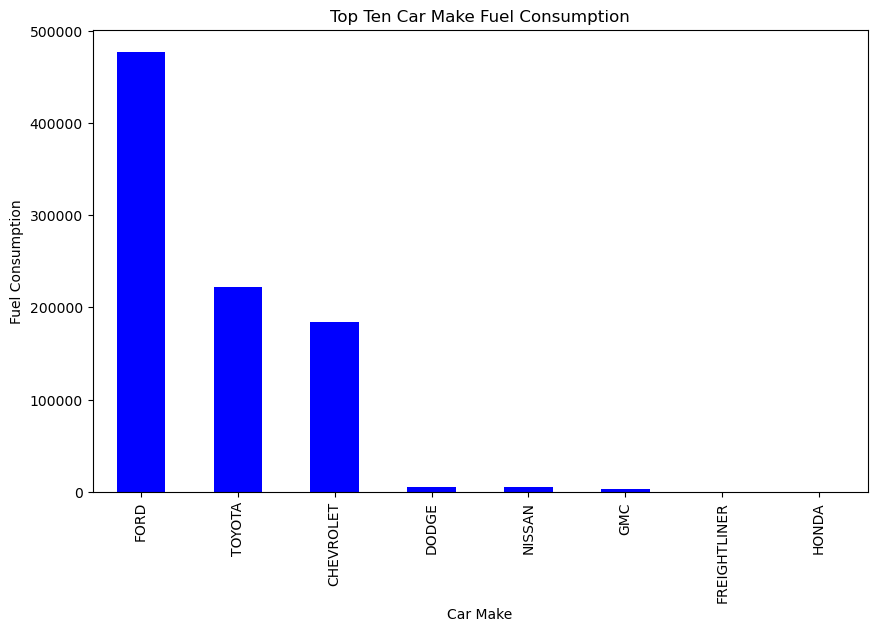

```python
# Plot the Fuel Consumtion for each Car Model

car_make =fuel_df.groupby('MAKE').sum()['TOTAL ACTUAL FUEL']

# Sort the values in descending order and select the top Car Makes
top_ten_car_make= car_make.sort_values(ascending=False).head(10)

# Display the result
print(top_ten_car_make)

# Plot the top ten Countries
top_ten_car_make.plot(kind='bar', color='blue',figsize=(10, 6))
plt.title('Top Ten Car Make Fuel Consumption')
plt.xlabel('Car Make')
plt.ylabel('Fuel Consumption')
plt.show()
```

Ford has the highest Fuel Consumption

# 2 Display bottom 10 Car Makes with the highest Fuel Consumption

```
MAKE
HONDA              221.0
FREIGHTLINER       296.0
GMC               3243.0
NISSAN            5037.0
DODGE             5199.0
CHEVROLET       183929.0
TOYOTA          222598.0
FORD            477336.5
Name: TOTAL ACTUAL FUEL, dtype: float64
```

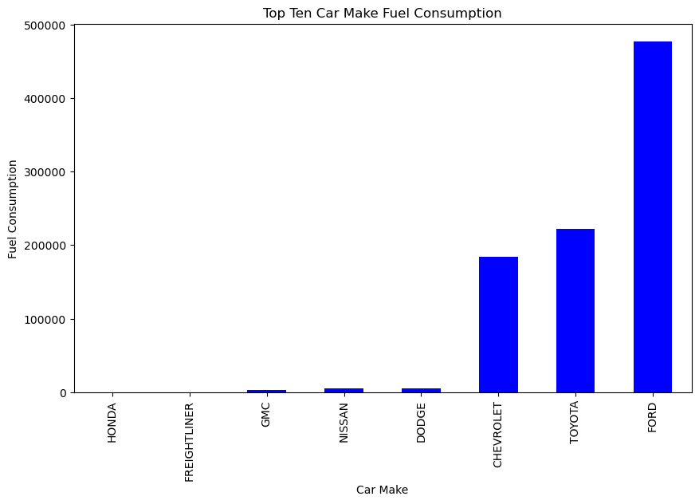

```python
# Plot the Fuel Consumtion for each Car Model

car_make =fuel_df.groupby('MAKE').sum()['TOTAL ACTUAL FUEL']

# Sort the values in descending order and select the top Car Makes
bottom_ten_car_make= car_make.sort_values(ascending=True).head(10)

# Display the result
print(bottom_ten_car_make)

# Plot the top ten Countries
bottom_ten_car_make.plot(kind='bar', color='blue',figsize=(10, 6))
plt.title('Top Ten Car Make Fuel Consumption')
plt.xlabel('Car Make')
plt.ylabel('Fuel Consumption')
plt.show()
```

Honda Has the lowest Fuel Consumption

# 3 Display top 10 Car Models with the highest Fuel Consumption

```
MODEL
PRIUS              145517.0
EXPRESS            118350.0
F150                99767.5
ESCAPE              89590.0
EXPLORER            41198.0
RAV4 HYBRID         40028.0
F250                38613.0
FUSION HYBRID       37974.0
TRANSIT CONNECT     27652.0
TAURUS              26022.0
Name: TOTAL ACTUAL FUEL, dtype: float64
```

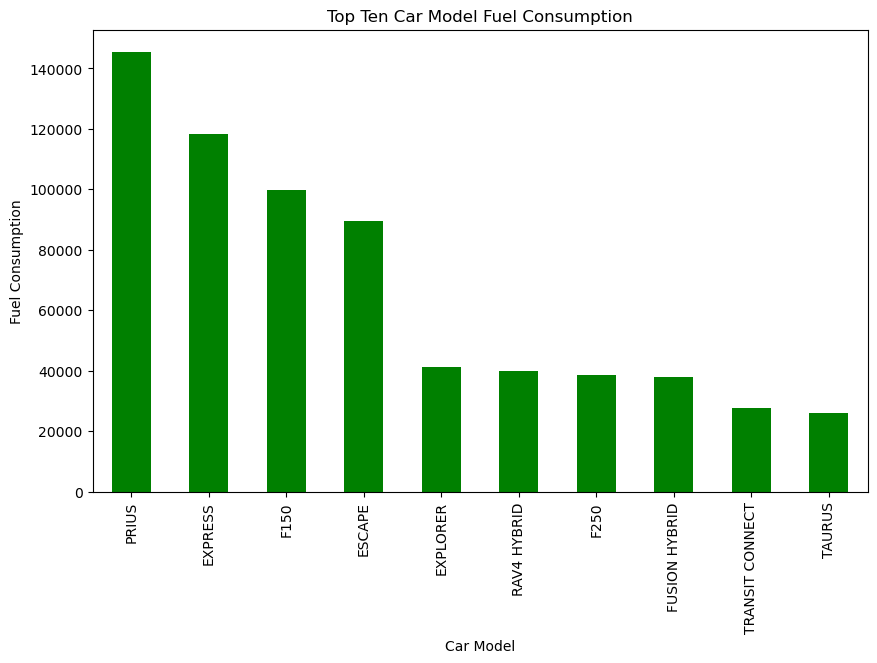

```python
# Plot the Fuel Consumtion for each Car Model

car_model =fuel_df.groupby('MODEL').sum()['TOTAL ACTUAL FUEL']

# Sort the values in descending order and select the top Car Makes
top_ten_car_model= car_model.sort_values(ascending=False).head(10)

# Display the result
print(top_ten_car_model)

# Plot the top ten Countries
top_ten_car_model.plot(kind='bar', color='green',figsize=(10, 6))
plt.title('Top Ten Car Model Fuel Consumption')
plt.xlabel('Car Model')
plt.ylabel('Fuel Consumption')
plt.show()
```

PRIUS has the highest Fuel Consumption

# 4 Display bottom 10 Car Models with the highest Fuel Consumption

```
MODEL
CIVIC GX             221.0
SPRINTER 3500        296.0
AVALON HYBRID        569.0
FOCUS                793.0
RANGER               845.0
CHARGER             1061.0
YUKON               1064.0
CROWN VIC           2061.0
YUKON XL            2179.0
SILVERADO HYBRID    4125.0
Name: TOTAL ACTUAL FUEL, dtype: float64
```

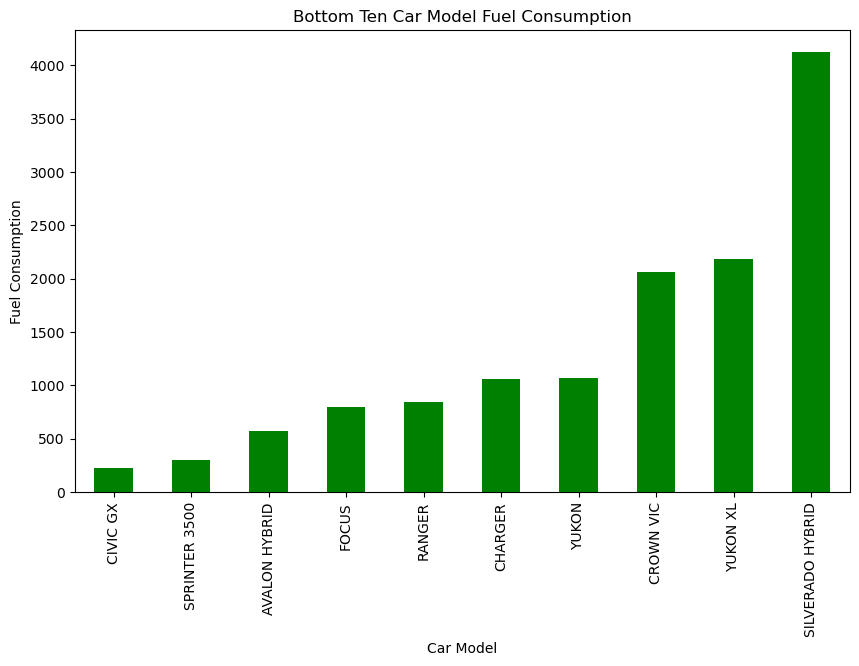

```python
# Plot the Fuel Consumtion for each Car Model

car_model =fuel_df.groupby('MODEL').sum()['TOTAL ACTUAL FUEL']

# Sort the values in descending order and select the top Car Makes
bottom_ten_car_model= car_model.sort_values(ascending=True).head(10)

# Display the result
print(bottom_ten_car_model)

# Plot the top ten Countries
bottom_ten_car_model.plot(kind='bar', color='green',figsize=(10, 6))
plt.title('Bottom Ten Car Model Fuel Consumption')
plt.xlabel('Car Model')
plt.ylabel('Fuel Consumption')
plt.show()
```

CIVIC GX has the lowest fuel consumption

# 5 Display Hybrid Cars Vs Non Hybrid Cars Distribution

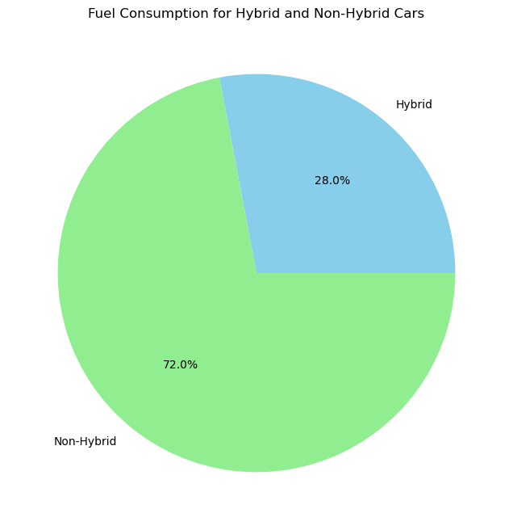

```python
# Plot the Fuel Cocumption for hybrid cars and non hybrid cars

hybrid_category =fuel_df.groupby('Hybrid/Non-Hybrid').sum()['TOTAL ACTUAL FUEL']

# Plot the pie chart
hybrid_category.plot(kind='pie', autopct='%1.1f%%', colors=['skyblue', 'lightgreen'], figsize=(8, 8))
plt.title('Fuel Consumption for Hybrid and Non-Hybrid Cars')
plt.ylabel('')  # No need for ylabel in pie chart
plt.show()
```

# 5 Display Car body type Fuel Consumption

```
STANDARD TYPE
SUV       274136.0
SEDAN     250728.0
VAN       207768.0
PICKUP    165227.5
Name: TOTAL ACTUAL FUEL, dtype: float64
```

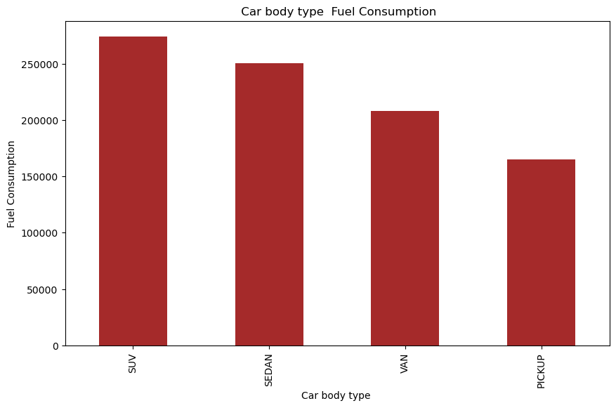

```python
# Plot the Fuel Consumtion for each Car Model

car_body_type =fuel_df.groupby('STANDARD TYPE').sum()['TOTAL ACTUAL FUEL']

# Sort the values in descending order and select the top Body type
top_ten_car_body_type= car_body_type.sort_values(ascending=False).head(10)

# Display the result
print(top_ten_car_body_type)

# Plot the top ten Countries
top_ten_car_body_type.plot(kind='bar', color='brown',figsize=(10, 6))
plt.title(' Car body type  Fuel Consumption')
plt.xlabel('Car body type ')
plt.ylabel('Fuel Consumption')
plt.show()
```

suv body types has the highest fuel consumption

Pickup body types has the lowest fuel consumption

```python
fuel_df.head(5)
```

|  | YEAR | MAKE | MODEL | Hybrid/Non-Hybrid | STANDARD TYPE | EPA RATING (CITY) | Vehicle Count | TOTAL ACTUAL MILES | TOTAL ACTUAL FUEL | EPA EXPECTED FUEL | ACTUAL FUEL ECONOMY Geotab | PERCENT % DIFFERENCE ACTUAL TO EPA | ESTIMATED FUEL COSTS PER GALLON | FUEL COSTS PER MILE |
| --- | --- | --- | --- | --- | --- | --- | --- | --- | --- | --- | --- | --- | --- | --- |
| 0 | 2008 | HONDA | CIVIC GX | Non-Hybrid | SEDAN | 24 | 9 | 4459 | 221.0 | 185.79 | 20.18 | -0.16 | $ 552.50 | $ 0.12 |
| 1 | 2008 | FORD | CROWN VIC | Non-Hybrid | SEDAN | 11 | 7 | 17162 | 1771.0 | 1560.18 | 9.69 | -0.12 | $ 4,427.50 | $ 0.26 |
| 2 | 2008 | CHEVROLET | EXPRESS | Non-Hybrid | VAN | 13 | 1 | 413 | 65.0 | 31.77 | 6.35 | -0.51 | $ 162.50 | $ 0.39 |
| 3 | 2008 | FORD | FOCUS | Non-Hybrid | SEDAN | 24 | 49 | 13074 | 793.0 | 544.75 | 16.49 | -0.31 | $ 1,982.50 | $ 0.15 |
| 4 | 2008 | FORD | FUSION | Non-Hybrid | SEDAN | 18 | 5 | 29482 | 1813.0 | 1637.89 | 16.26 | -0.10 | $ 4,532.50 | $ 0.15 |

# Case Study 1: Ford

```python
# Selecting data for Honda
Ford_data = fuel_df[fuel_df['MAKE'] == "FORD"]

# Extracting specific columns
Fordf1 = Ford_data ['Vehicle Count']
Fordf2 = Ford_data ['TOTAL ACTUAL FUEL']

# Checking if both conditions hold true
Ford_filtered_data = Ford_data[(Fordf1.notnull()) & (Fordf2.notnull())]

Ford_filtered_data.head(5)
```

|  | YEAR | MAKE | MODEL | Hybrid/Non-Hybrid | STANDARD TYPE | EPA RATING (CITY) | Vehicle Count | TOTAL ACTUAL MILES | TOTAL ACTUAL FUEL | EPA EXPECTED FUEL | ACTUAL FUEL ECONOMY Geotab | PERCENT % DIFFERENCE ACTUAL TO EPA | ESTIMATED FUEL COSTS PER GALLON | FUEL COSTS PER MILE |
| --- | --- | --- | --- | --- | --- | --- | --- | --- | --- | --- | --- | --- | --- | --- |
| 1 | 2008 | FORD | CROWN VIC | Non-Hybrid | SEDAN | 11 | 7 | 17162 | 1771.0 | 1560.18 | 9.69 | -0.12 | $ 4,427.50 | $ 0.26 |
| 3 | 2008 | FORD | FOCUS | Non-Hybrid | SEDAN | 24 | 49 | 13074 | 793.0 | 544.75 | 16.49 | -0.31 | $ 1,982.50 | $ 0.15 |
| 4 | 2008 | FORD | FUSION | Non-Hybrid | SEDAN | 18 | 5 | 29482 | 1813.0 | 1637.89 | 16.26 | -0.10 | $ 4,532.50 | $ 0.15 |
| 7 | 2008 | FORD | RANGER | Non-Hybrid | PICKUP | 15 | 14 | 8820 | 845.0 | 588.00 | 10.44 | -0.30 | $ 2,112.50 | $ 0.24 |
| 9 | 2009 | FORD | CROWN VIC | Non-Hybrid | SEDAN | 16 | 39 | 3263 | 290.0 | 203.94 | 11.25 | -0.30 | $ 725.00 | $ 0.22 |

```python
Ford_filtered_data.describe()
```

|  | YEAR | EPA RATING (CITY) | Vehicle Count | TOTAL ACTUAL MILES | TOTAL ACTUAL FUEL | EPA EXPECTED FUEL | ACTUAL FUEL ECONOMY Geotab | PERCENT % DIFFERENCE ACTUAL TO EPA |
| --- | --- | --- | --- | --- | --- | --- | --- | --- |
| count | 55.00000 | 55.000000 | 55.000000 | 55.000000 | 55.000000 | 55.000000 | 55.000000 | 55.000000 |
| mean | 2013.60000 | 19.981818 | 29.163636 | 124784.927273 | 8678.845455 | 6577.763636 | 15.788364 | -0.209818 |
| std | 3.18329 | 8.154733 | 36.182031 | 140896.517633 | 9032.667358 | 6769.011186 | 8.346563 | 0.221138 |
| min | 2008.00000 | 10.000000 | 5.000000 | 3263.000000 | 289.000000 | 203.940000 | 6.620000 | -0.560000 |
| 25% | 2011.00000 | 15.000000 | 9.000000 | 32502.000000 | 1897.000000 | 1449.540000 | 10.425000 | -0.380000 |
| 50% | 2014.00000 | 18.000000 | 16.000000 | 83488.000000 | 5681.000000 | 4538.200000 | 12.470000 | -0.210000 |
| 75% | 2016.00000 | 21.500000 | 30.500000 | 161921.500000 | 10707.750000 | 8714.580000 | 16.695000 | -0.090000 |
| max | 2019.00000 | 43.000000 | 189.000000 | 689589.000000 | 40809.000000 | 32837.570000 | 41.460000 | 0.520000 |

Ford vehicle were mostly used between 2012 to 2014

```python
import plotly.express as px

# Plot relationship between life expectancy and years
fig = px.bar(Ford_filtered_data, x='YEAR', y='TOTAL ACTUAL FUEL', height=320, labels={'TOTAL ACTUAL FUEL':'Fuel Consumption'}, title='Relationship between Fuel Consumption and Years - Ford')
fig.update_layout(xaxis_tickangle=-45)  # Rotate x-axis labels for better readability

# Show the plot
fig.show()
```

[interactive chart not shown]

Between 2016 and 2018 Ford vehicle had the highest Fuel Consumption

# Case Study 2: PRIUS

```python
# Selecting data for Honda
PRIUS_data = fuel_df[fuel_df['MODEL'] == "PRIUS"]

# Extracting specific columns
PRIUSf1 = PRIUS_data['Vehicle Count']
PRIUSf2 = PRIUS_data['TOTAL ACTUAL FUEL']

# Checking if both conditions hold true
PRIUS_filtered_data = PRIUS_data[(PRIUSf1.notnull()) & (PRIUSf2.notnull())]

PRIUS_filtered_data.head(5)
```

|  | YEAR | MAKE | MODEL | Hybrid/Non-Hybrid | STANDARD TYPE | EPA RATING (CITY) | Vehicle Count | TOTAL ACTUAL MILES | TOTAL ACTUAL FUEL | EPA EXPECTED FUEL | ACTUAL FUEL ECONOMY Geotab | PERCENT % DIFFERENCE ACTUAL TO EPA | ESTIMATED FUEL COSTS PER GALLON | FUEL COSTS PER MILE |
| --- | --- | --- | --- | --- | --- | --- | --- | --- | --- | --- | --- | --- | --- | --- |
| 6 | 2008 | TOYOTA | PRIUS | Hybrid | SEDAN | 48 | 189 | 1034445 | 25453.0 | 21550.94 | 40.64 | -0.15 | $ 63,632.50 | $ 0.06 |
| 13 | 2009 | TOYOTA | PRIUS | Hybrid | SEDAN | 48 | 86 | 341538 | 8249.0 | 7115.38 | 41.40 | -0.14 | $ 20,622.50 | $ 0.06 |
| 18 | 2010 | TOYOTA | PRIUS | Hybrid | SEDAN | 51 | 84 | 266257 | 5760.0 | 5220.73 | 46.23 | -0.09 | $ 14,400.00 | $ 0.05 |
| 26 | 2011 | TOYOTA | PRIUS | Hybrid | SEDAN | 49 | 86 | 374960 | 7968.0 | 7652.24 | 47.06 | -0.04 | $ 19,920.00 | $ 0.05 |
| 38 | 2012 | TOYOTA | PRIUS | Hybrid | SEDAN | 49 | 15 | 55592 | 1184.0 | 1134.53 | 46.95 | -0.04 | $ 2,960.00 | $ 0.05 |

```python
import plotly.express as px

# Plot relationship between life expectancy and years
fig = px.bar(PRIUS_filtered_data, x='YEAR', y='TOTAL ACTUAL FUEL', height=320, labels={'TOTAL ACTUAL FUEL':'Fuel Consumption'}, title='Relationship between Fuel Consumption and Years - PRIUS')
fig.update_layout(xaxis_tickangle=-45)  # Rotate x-axis labels for better readability

# Show the plot
fig.show()
```

[interactive chart not shown]

Prius models had the highest fuel consumption between 2015 and 2016

# Case Study 3: SUV Body type

```python
# Selecting data for Honda
SUV_data = fuel_df[fuel_df['STANDARD TYPE'] == "SUV"]

# Extracting specific columns
SUVf1 = SUV_data['Vehicle Count']
SUVf2 = SUV_data['TOTAL ACTUAL FUEL']

# Checking if both conditions hold true
SUV_filtered_data = SUV_data[(SUVf1.notnull()) & (SUVf2.notnull())]

SUV_filtered_data.head(3)
```

|  | YEAR | MAKE | MODEL | Hybrid/Non-Hybrid | STANDARD TYPE | EPA RATING (CITY) | Vehicle Count | TOTAL ACTUAL MILES | TOTAL ACTUAL FUEL | EPA EXPECTED FUEL | ACTUAL FUEL ECONOMY Geotab | PERCENT % DIFFERENCE ACTUAL TO EPA | ESTIMATED FUEL COSTS PER GALLON | FUEL COSTS PER MILE |
| --- | --- | --- | --- | --- | --- | --- | --- | --- | --- | --- | --- | --- | --- | --- |
| 5 | 2008 | TOYOTA | HIGHLANDER HYBRID | Hybrid | SUV | 27 | 15 | 36095 | 1667.0 | 1336.85 | 21.65 | -0.20 | $ 4,167.50 | $ 0.12 |
| 10 | 2009 | FORD | ESCAPE | Non-Hybrid | SUV | 19 | 14 | 3903 | 430.0 | 205.42 | 9.08 | -0.52 | $ 1,075.00 | $ 0.28 |
| 11 | 2009 | FORD | ESCAPE HYBRID | Hybrid | SUV | 34 | 32 | 180992 | 8729.0 | 5323.29 | 20.73 | -0.39 | $ 21,822.50 | $ 0.12 |

```python
# Plot relationship between life expectancy and years
fig = px.bar(SUV_filtered_data, x='YEAR', y='TOTAL ACTUAL FUEL', height=320, labels={'TOTAL ACTUAL FUEL':'Fuel Consumption'}, title='SUV Fuel Consuption Histogram - SUVS')
fig.update_layout(xaxis_tickangle=-45)  # Rotate x-axis labels for better readability

# Show the plot
fig.show()
```

[interactive chart not shown]

SUVs had the highest fuel consumption between 2014 to 2016

# Conclusion

1.Ford has the highest Fuel Consumption

2.HPRIUS has the highest Fuel Consumption

3.Honda Has the lowest Fuel Consumption

4.CIVIC GX has the lowest fuel consumption

6.suv body types has the highest fuel consumption

7.Pickup body types has the lowest fuel consumption

8.Between 2016 and 2018 Ford vehicle had the highest Fuel Consumption

9.Prius models had the highest fuel consumption between 2015 and 2016

10.SUVs had the highest fuel consumption between 2014 to 2016